# R Notebook - 3 Data visualisation

R for Data Science

```r
#intall.packages("tidyverse")
library(tidyverse)
```

```r
#Import data
?ggplot2::mpg
mpg
```

| manufacturer | model | displ | year | cyl | trans | drv | cty | hwy | fl | class |
| --- | --- | --- | --- | --- | --- | --- | --- | --- | --- | --- |
| audi | a4 | 1.8 | 1999 | 4 | auto(l5) | f | 18 | 29 | p | compact |
| audi | a4 | 1.8 | 1999 | 4 | manual(m5) | f | 21 | 29 | p | compact |
| audi | a4 | 2.0 | 2008 | 4 | manual(m6) | f | 20 | 31 | p | compact |
| audi | a4 | 2.0 | 2008 | 4 | auto(av) | f | 21 | 30 | p | compact |
| audi | a4 | 2.8 | 1999 | 6 | auto(l5) | f | 16 | 26 | p | compact |
| audi | a4 | 2.8 | 1999 | 6 | manual(m5) | f | 18 | 26 | p | compact |
| audi | a4 | 3.1 | 2008 | 6 | auto(av) | f | 18 | 27 | p | compact |
| audi | a4 quattro | 1.8 | 1999 | 4 | manual(m5) | 4 | 18 | 26 | p | compact |
| audi | a4 quattro | 1.8 | 1999 | 4 | auto(l5) | 4 | 16 | 25 | p | compact |
| audi | a4 quattro | 2.0 | 2008 | 4 | manual(m6) | 4 | 20 | 28 | p | compact |

[output cut: 224 more lines]

```r
str(mpg)
```

```
tibble [234 × 11] (S3: tbl_df/tbl/data.frame)
 $ manufacturer: chr [1:234] "audi" "audi" "audi" "audi" ...
 $ model       : chr [1:234] "a4" "a4" "a4" "a4" ...
 $ displ       : num [1:234] 1.8 1.8 2 2 2.8 2.8 3.1 1.8 1.8 2 ...
 $ year        : int [1:234] 1999 1999 2008 2008 1999 1999 2008 1999 1999 2008 ...
 $ cyl         : int [1:234] 4 4 4 4 6 6 6 4 4 4 ...
 $ trans       : chr [1:234] "auto(l5)" "manual(m5)" "manual(m6)" "auto(av)" ...
 $ drv         : chr [1:234] "f" "f" "f" "f" ...
 $ cty         : int [1:234] 18 21 20 21 16 18 18 18 16 20 ...
 $ hwy         : int [1:234] 29 29 31 30 26 26 27 26 25 28 ...
 $ fl          : chr [1:234] "p" "p" "p" "p" ...
 $ class       : chr [1:234] "compact" "compact" "compact" "compact" ...
```

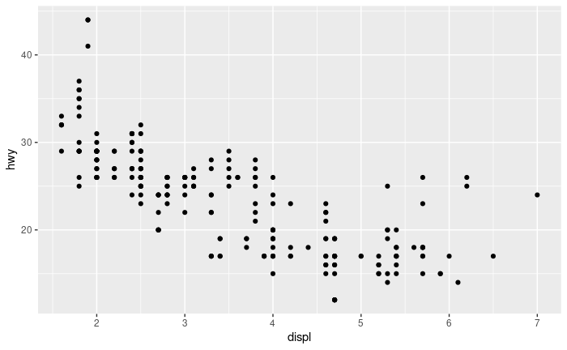

```r
ggplot(data=mpg) +
  geom_point(mapping = aes(x=displ, y=hwy))
```

3.2.4 Exercises  
1. Run ggplot(data = mpg). What do you see?  
2. How many rows are in mpg? How many columns?  
3. What does the drv variable describe? Read the help for ?mpg to find out.  
4. Make a scatterplot of hwy vs cyl.  
5. What happens if you make a scatterplot of class vs drv? Why is the plot not useful?

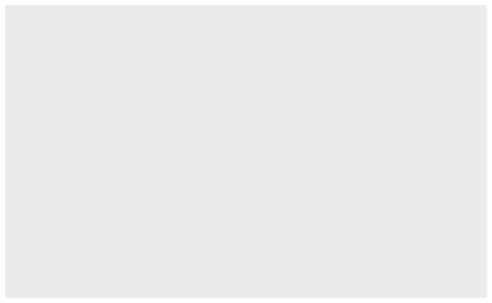

```r
#1.
ggplot(data=mpg)
```

```r
#2.
dim(mpg)
```

```
[1] 234  11
```

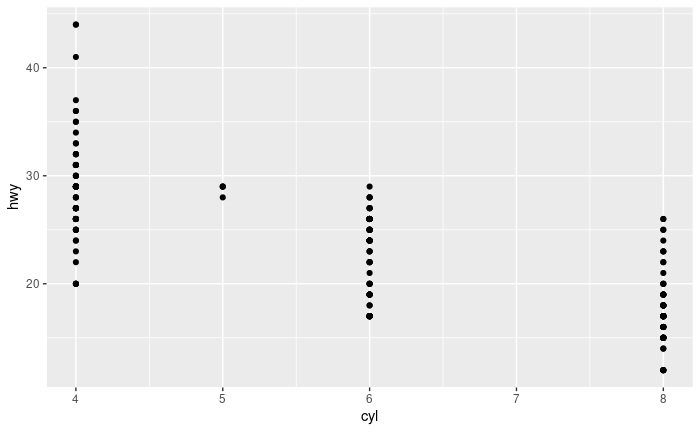

```r
#3.
?mpg
#the type of drive train, where f = front-wheel drive, r = rear wheel drive, 4 = 4wd

#4.
ggplot(data = mpg) +
  geom_point(mapping = aes(x=cyl, y=hwy))
```

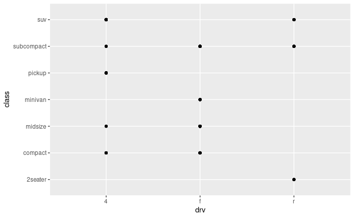

```r
#Observa-se que carros com menor quantidade de cilindros tendem a apresentar uma maior eficiência.

#5.
ggplot(data = mpg) +
  geom_point(mapping = aes(x=drv, y=class))
```

```r
#Um scatter plot dessas features não é muito útil pois ambos os dados são categoricos, apresentados grande overlap sobre seus valores.
```

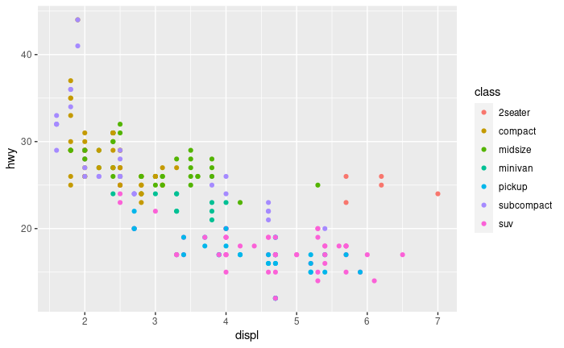

```r
ggplot(data = mpg) +
  geom_point(mapping = aes(x=displ, y=hwy, color=class))
```

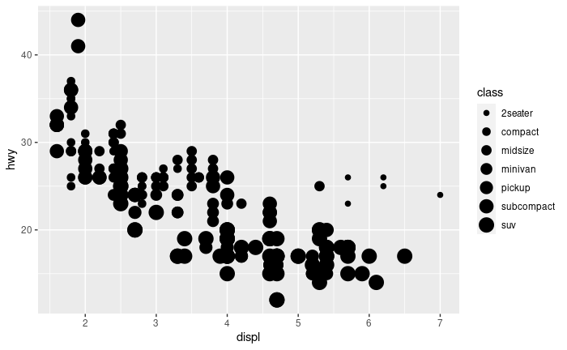

```r
ggplot(data = mpg) +
  geom_point(mapping = aes(x=displ, y=hwy, size=class))
```

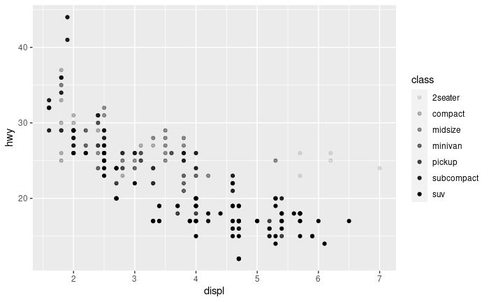

```r
ggplot(data = mpg) +
  geom_point(mapping = aes(x=displ, y=hwy, alpha=class))
```

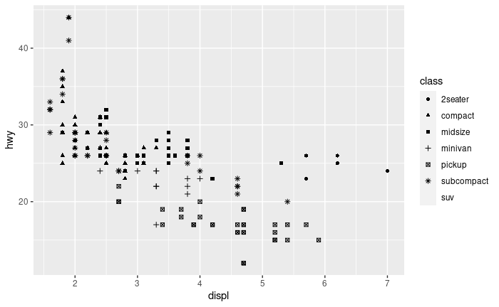

```r
ggplot(data = mpg) +
  geom_point(mapping = aes(x=displ, y=hwy, shape=class))
```

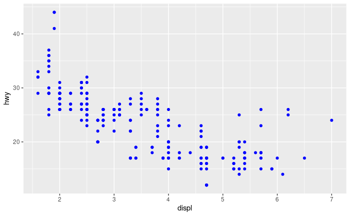

```r
ggplot(data= mpg) +
  geom_point(mapping = aes(x=displ, y=hwy), color='blue')
```

3.3.1 Exercises 2. Which variables in mpg are categorical? Which variables are continuous? (Hint: type ?mpg to read the documentation for the dataset). How can you see this information when you run mpg?  
3. Map a continuous variable to color, size, and shape. How do these aesthetics behave differently for categorical vs. continuous variables? 4. What happens if you map the same variable to multiple aesthetics? 5. What does the stroke aesthetic do? What shapes does it work with? (Hint: use ?geom_point) 6. What happens if you map an aesthetic to something other than a variable name, like aes(colour = displ < 5)? Note, you’ll also need to specify x and y.

```r
#2.
str(mpg)
```

```
tibble [234 × 11] (S3: tbl_df/tbl/data.frame)
 $ manufacturer: chr [1:234] "audi" "audi" "audi" "audi" ...
 $ model       : chr [1:234] "a4" "a4" "a4" "a4" ...
 $ displ       : num [1:234] 1.8 1.8 2 2 2.8 2.8 3.1 1.8 1.8 2 ...
 $ year        : int [1:234] 1999 1999 2008 2008 1999 1999 2008 1999 1999 2008 ...
 $ cyl         : int [1:234] 4 4 4 4 6 6 6 4 4 4 ...
 $ trans       : chr [1:234] "auto(l5)" "manual(m5)" "manual(m6)" "auto(av)" ...
 $ drv         : chr [1:234] "f" "f" "f" "f" ...
 $ cty         : int [1:234] 18 21 20 21 16 18 18 18 16 20 ...
 $ hwy         : int [1:234] 29 29 31 30 26 26 27 26 25 28 ...
 $ fl          : chr [1:234] "p" "p" "p" "p" ...
 $ class       : chr [1:234] "compact" "compact" "compact" "compact" ...
```

```r
#Observando o emprego de "str" sobre os dados, a maioria dos dados são categóricos, podendo ser representado como feature contínua as variáveis "dipl", "hwy" e "cty".
```

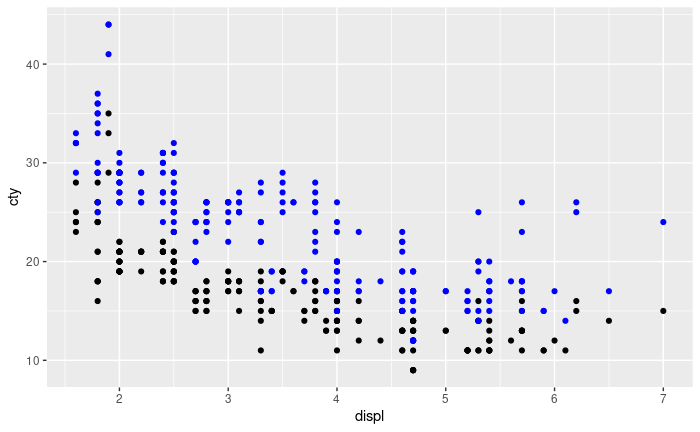

```r
ggplot(data = mpg) +
  geom_point(mapping = aes(x=displ, y=cty)) +
  geom_point(mapping = aes(x=displ, y=hwy), color='blue')
```

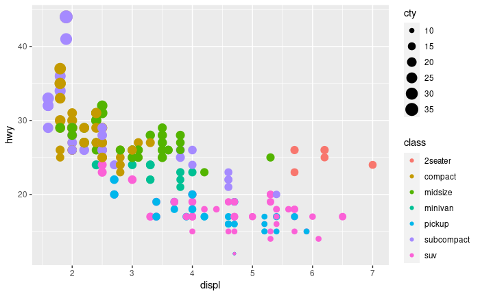

```r
#3.
ggplot(data = mpg) +
  geom_point(mapping = aes(x=displ, y=hwy, size=cty, color=class))
```

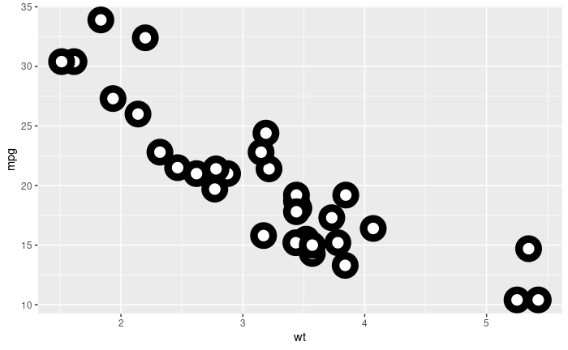

```r
ggplot(data = mtcars, aes(x=wt, y=mpg)) +
  geom_point(shape=21, colour='black', fill='white', size=5, stroke = 5)
```

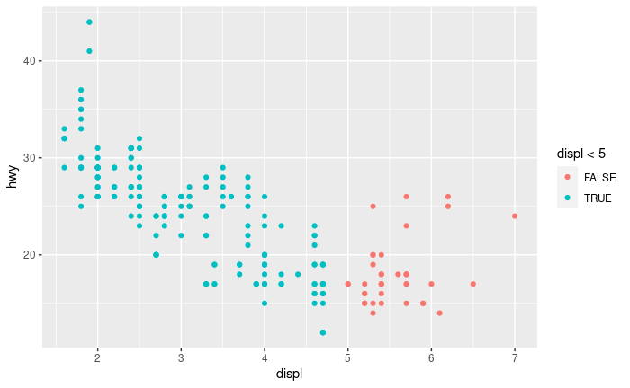

```r
ggplot(data = mpg) +
  geom_point(mapping = aes(x=displ, y=hwy, colour = displ < 5))
```

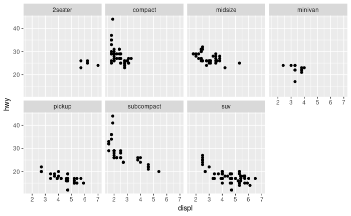

```r
ggplot(data = mpg) +
  geom_point(mapping = aes(x=displ, y=hwy)) +
  facet_wrap(~ class, nrow=2)
```

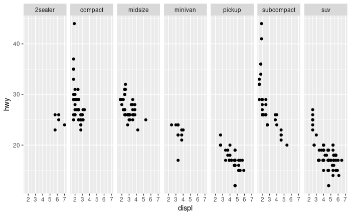

```r
ggplot(data = mpg) +
  geom_point(mapping = aes(x=displ, y=hwy)) +
  facet_grid(. ~ class)
```

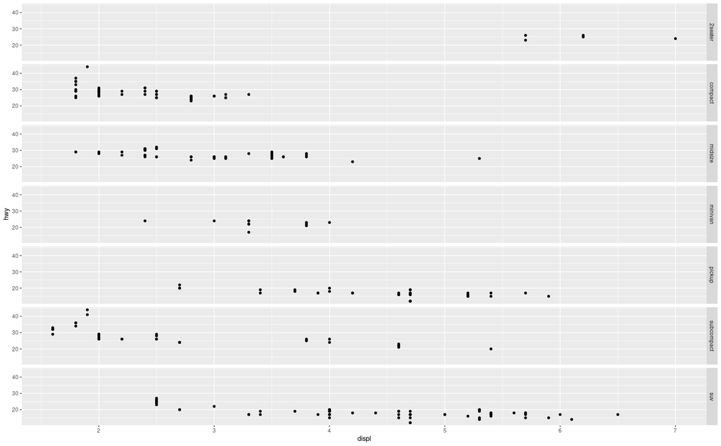

```r
ggplot(data = mpg) +
  geom_point(mapping = aes(x=displ, y=hwy)) +
  facet_grid(class ~ .)
```

3.5.1 Exercises

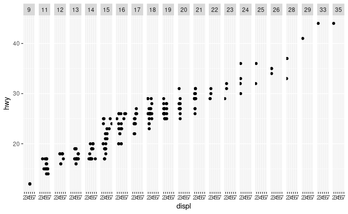

```r
ggplot(data = mpg) +
  geom_point(mapping = aes(x=displ, y=hwy)) +
  facet_grid(. ~ cty)
```

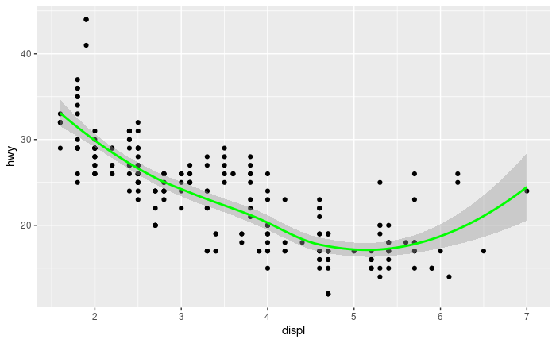

```r
ggplot(data = mpg) +
  geom_point(mapping = aes(x=displ, y=hwy)) +
  geom_smooth(mapping = aes(x=displ, y=hwy), color='green')
```

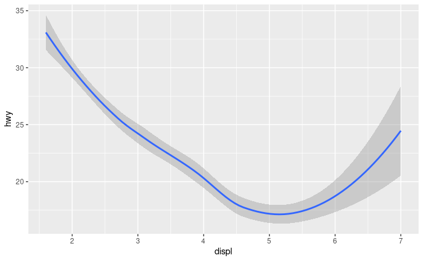

```r
ggplot(data = mpg) +
  geom_smooth(mapping = aes(x=displ, y=hwy))
```

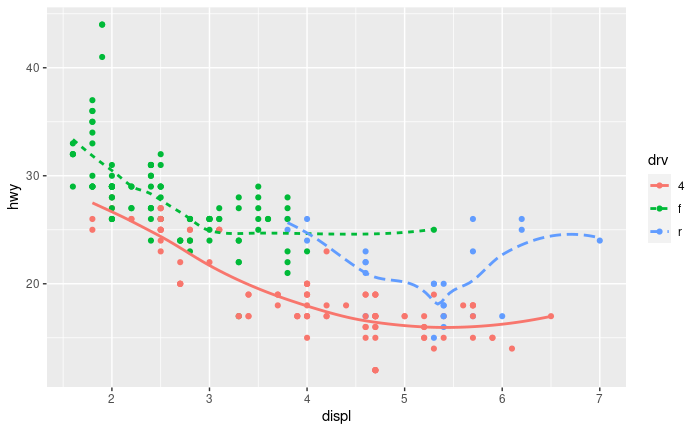

```r
ggplot(data = mpg, mapping = aes(x=displ, y=hwy)) +
  geom_point(mapping = aes(color=drv)) +
  geom_smooth(mapping = aes(linetype = drv, color = drv), se=FALSE)
```

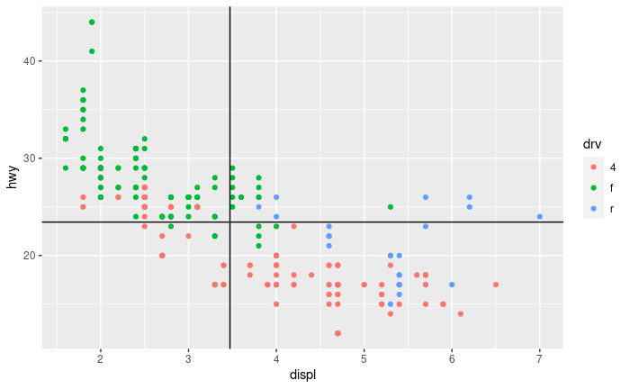

```r
ggplot(data = mpg, mapping = aes(x=displ, y=hwy)) +
  geom_point(mapping = aes(color=drv)) +
  geom_vline(xintercept = mean(mpg$displ)) +
  geom_hline(yintercept = mean(mpg$hwy))
```

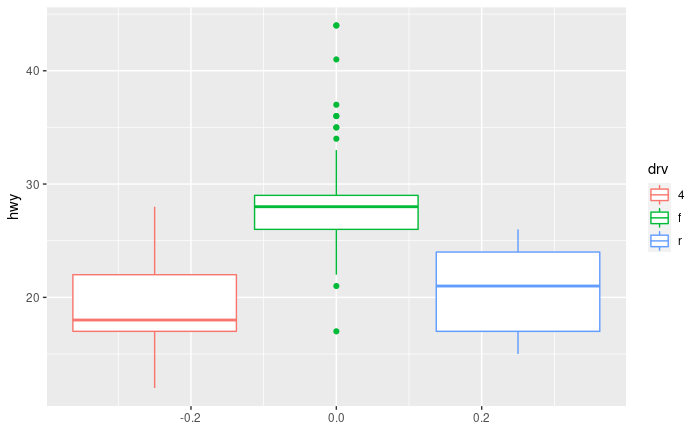

```r
ggplot(data = mpg) +
  geom_boxplot(mapping = aes(y=hwy, color=drv))
```

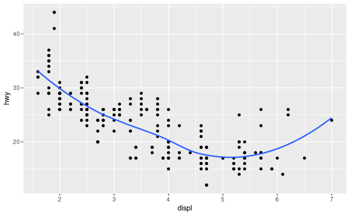

```r
ggplot(data = mpg, mapping = aes(x=displ, y=hwy)) +
  geom_point() +
  geom_smooth(se=FALSE)
```

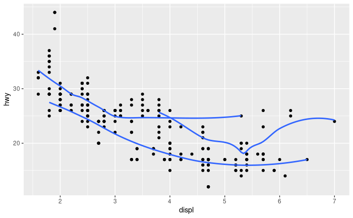

```r
ggplot(data = mpg, mapping = aes(x=displ, y=hwy)) +
  geom_point() +
  geom_smooth(mapping = aes(group=drv), se=FALSE)
```

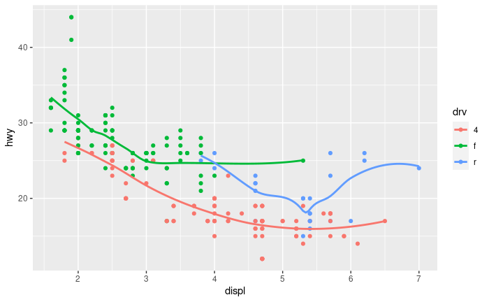

```r
ggplot(data = mpg, mapping= aes(x=displ, y=hwy)) +
  geom_point(mapping = aes(color=drv)) +
  geom_smooth(mapping = aes(color=drv), se=FALSE)
```